# Culture After Six NYC

## tl;dr

This project asks: **When is geographic proximity a poor measure of cultural access, and how do departure time, subway travel, admission, opening hours, step-free proximity, and personal interest change where someone can actually go?**

The analytical pilot contains 25 visit profiles with structured weekly hours and admission rules. The public-use product expands discovery and routing to **161 screened cultural places across all five boroughs**, each with a public address, description, official website, current-program link, category, source-backed visit information, and modeled route. One hundred six of those public venues include structured weekly hours. A separate editorial layer contains **16 date-checked current programs**.

Within the 25-profile analysis, the median venue is **394 meters from a subway stop** but **604 meters from an ADA-accessible stop**. Walking-network trips from Columbia are typically **15% longer than straight-line distance**. In the example Friday-evening scenario, **9 of 25 pilot venues** are both open and affordable.

The key finding is not that New York lacks culture. It is that cultural abundance, geographic proximity, and practical cultural access are different things.

## Context & Methods

This final expands the **Networks** assignment into a public-facing cultural access tool. The personal starting point is a common after-class question: where could a Columbia student realistically go tonight?

### Key Assumptions

- Twenty-five pilot venues support the detailed weekly hours-and-price analysis; the larger 161-place product supports routing, discovery, source-backed visit information, official links, and personalized recommendations. One hundred six public venues have structured weekly hours for arrival-time filtering.
- Subway travel uses a typical weekday MTA GTFS schedule, plus four minutes for initial waiting and modeled transfer penalties. It is not live trip planning.
- Up to eight nearby destination stations are compared so the geometrically nearest stop does not automatically determine the route.
- Pay-what-you-wish admission is represented as $1 for numeric comparison.
- Public access, addresses, and official links were checked on August 1, 2026. Hours, prices, programs, and transit conditions can change.
- Being nearby, open, and affordable still cannot measure whether a space feels socially welcoming or whether its programming is culturally relevant.

```python
from pathlib import Path
import datetime as dt
import json

import geopandas as gpd
import matplotlib.pyplot as plt
from matplotlib.lines import Line2D
import numpy as np
import osmnx as ox
import pandas as pd
from shapely.geometry import LineString

PROJECT_DIR = Path.cwd()
if PROJECT_DIR.name == "notebooks":
    PROJECT_DIR = PROJECT_DIR.parent

DATA_DIR = PROJECT_DIR / "data"
FIGURE_DIR = PROJECT_DIR / "figures"
FIGURE_DIR.mkdir(exist_ok=True)

CORAL = "#F05A47"
GREEN = "#1F6B5C"
BLUE = "#2D5BFF"
INK = "#1B1B1B"
MUTED = "#8A8A84"
PAPER = "#F7F6F1"

plt.rcParams.update({
    "figure.facecolor": PAPER,
    "axes.facecolor": PAPER,
    "axes.edgecolor": INK,
    "axes.labelcolor": INK,
    "text.color": INK,
    "font.size": 11,
    "axes.titleweight": "bold",
})
```

## Data

The analytical pilot begins with NYC Department of Cultural Affairs data, DCLA's admission guide, official venue pages, MTA stations and GTFS schedules, and OpenStreetMap walking paths. The public-use layer was then individually screened and expanded with additional museums, galleries, cinemas, performance spaces, cultural centers, archives, artist-run spaces, and community arts organizations.

Three cultural layers remain distinct:

1. **25 structured weekly profiles** contain regular hours and price rules for reproducible time-and-budget analysis.
2. **161 screened public places** contain public addresses, descriptions, categories, official websites, program links, admission and opening-schedule information, and the fields needed for browser-side route calculation. One hundred six have structured weekly schedules.
3. **16 current programs** form a date-checked editorial sample with official links and automatic expiration dates.

The larger 2,268-point DCLA coordinate layer remains useful for coverage analysis, but a directory coordinate may be an office or mailing address and is not automatically treated as a visitable venue.

```python
venues = gpd.read_file(DATA_DIR / "venues.geojson")
public_places = gpd.read_file(DATA_DIR / "cultural_places.geojson")
stations = gpd.read_file(DATA_DIR / "subway_stations.geojson")
directory = gpd.read_file(DATA_DIR / "dcla_organizations.geojson")
transit_routes = gpd.read_file(DATA_DIR / "columbia_transit_routes.geojson")
current_programs = pd.DataFrame(
    json.loads((DATA_DIR / "current_programs.json").read_text())
)
summary = json.loads((DATA_DIR / "analysis_summary.json").read_text())
subway_network = json.loads((DATA_DIR / "subway_network.json").read_text())

venues["hours"] = venues["hours"].apply(
    lambda value: json.loads(value) if isinstance(value, str) else value
)
venues["access_programs"] = venues["access_programs"].apply(
    lambda value: json.loads(value) if isinstance(value, str) else value
)
venues["data_checked"] = pd.to_datetime(venues["data_checked"]).dt.date

print(f"Screened public places with routes: {len(public_places):,}")
print(f"Full hours-and-price profiles: {len(venues):,}")
print(f"Date-checked current programs: {len(current_programs):,}")
print(f"Geocoded DCLA directory records: {len(directory):,}")
print(f"Subway station records: {len(stations):,}")
print(
    "Station-line network: "
    f"{summary['subway_network_node_count']:,} nodes / "
    f"{summary['subway_network_edge_count']:,} directed edges"
)
print("Public-place data checked: 2026-08-01")
display(
    public_places[
        ["name", "category", "venue_type", "borough", "neighborhood"]
    ].head(8)
)
```

```
Screened public places with routes: 161
Full hours-and-price profiles: 25
Date-checked current programs: 16
Geocoded DCLA directory records: 2,268
Subway station records: 496
Station-line network: 1,002 nodes / 4,337 directed edges
Public-place data checked: 2026-08-01
```

|  | name | category | venue_type | borough | neighborhood |
| --- | --- | --- | --- | --- | --- |
| 0 | 9/11 Memorial & Museum | Museums & Heritage | History museum | Manhattan | Financial District |
| 1 | Asia Society Museum | Cultural Centers | Museum and cultural center | Manhattan | Upper East Side |
| 2 | China Institute Gallery | Cultural Centers | Gallery and cultural center | Manhattan | Financial District |
| 3 | Cooper Hewitt, Smithsonian Design Museum | Design, Books & Architecture | Design museum | Manhattan | Carnegie Hill |
| 4 | The Frick Collection | Museums & Heritage | Art museum | Manhattan | Upper East Side |
| 5 | Solomon R. Guggenheim Museum | Art & Exhibitions | Modern art museum | Manhattan | Upper East Side |
| 6 | International Center of Photography | Art & Exhibitions | Photography museum | Manhattan | Lower East Side |
| 7 | Japan Society Gallery | Cultural Centers | Gallery and cultural center | Manhattan | Midtown East |

```python
required = [
    "name",
    "geometry",
    "hours",
    "adult_price",
    "student_price",
    "station_walk_m",
    "ada_station_walk_m",
    "columbia_euclidean_m",
    "columbia_walk_network_m",
]

quality = pd.DataFrame({
    "check": [
        "Venue identifiers are unique",
        "Required fields are complete",
        "Coordinates fall within NYC bounds",
        "Network distances are positive",
        "Official source links are present",
    ],
    "passes": [
        venues["id"].is_unique,
        venues[required].notna().all().all(),
        venues.geometry.x.between(-74.05, -73.90).all()
        and venues.geometry.y.between(40.68, 40.90).all(),
        (venues["columbia_walk_network_m"] > 0).all(),
        venues["website"].str.startswith("https://").all(),
    ],
})
display(quality)
```

|  | check | passes |
| --- | --- | --- |
| 0 | Venue identifiers are unique | True |
| 1 | Required fields are complete | True |
| 2 | Coordinates fall within NYC bounds | True |
| 3 | Network distances are positive | True |
| 4 | Official source links are present | True |

### What the attributes mean

- `station_walk_m` is network distance from the venue to the nearest subway stop.
- `ada_station_walk_m` repeats the calculation using only fully or partially accessible stops.
- `columbia_euclidean_m` is straight-line distance from Avery Hall.
- `columbia_walk_network_m` follows the walkable street and path network.
- Hours and access programs are separate so the analysis can distinguish **being open** from **being affordable**.

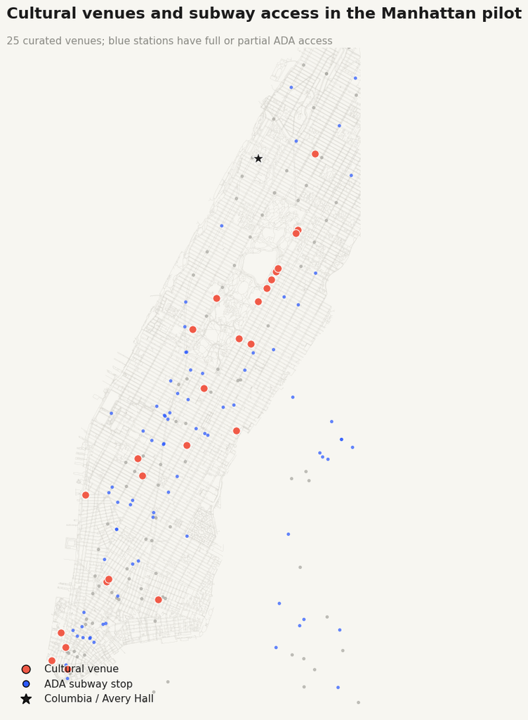

```python
graph = ox.load_graphml(DATA_DIR / "manhattan_walk.graphml")
edges = ox.graph_to_gdfs(graph, nodes=False, edges=True)

fig, ax = plt.subplots(figsize=(9, 11))
edges.plot(ax=ax, color="#D8D6CF", linewidth=0.18, alpha=0.7, zorder=1)
stations.plot(
    ax=ax,
    color=np.where(stations["ada"] > 0, BLUE, "#A9A8A2"),
    markersize=7,
    alpha=0.65,
    zorder=2,
)
venues.plot(
    ax=ax,
    color=CORAL,
    edgecolor="white",
    linewidth=0.8,
    markersize=70,
    zorder=3,
)
ax.scatter(
    -73.96255,
    40.80766,
    marker="*",
    s=180,
    color=INK,
    edgecolor="white",
    linewidth=0.8,
    zorder=4,
)
ax.set_xlim(-74.03, -73.935)
ax.set_ylim(40.695, 40.83)
ax.set_title(
    "Cultural venues and subway access in the Manhattan pilot",
    loc="left",
    fontsize=17,
    pad=32,
)
ax.text(
    0,
    1.005,
    "25 curated venues; blue stations have full or partial ADA access",
    transform=ax.transAxes,
    color=MUTED,
)
ax.axis("off")
ax.legend(
    handles=[
        Line2D([0], [0], marker="o", color="none", markerfacecolor=CORAL, markersize=9, label="Cultural venue"),
        Line2D([0], [0], marker="o", color="none", markerfacecolor=BLUE, markersize=7, label="ADA subway stop"),
        Line2D([0], [0], marker="*", color="none", markerfacecolor=INK, markersize=12, label="Columbia / Avery Hall"),
    ],
    loc="lower left",
    frameon=False,
)
fig.tight_layout()
fig.savefig(FIGURE_DIR / "01_venues_and_subway.png", dpi=180, bbox_inches="tight")
plt.show()
```

## Results

The following function evaluates three different questions for a specific date, time, budget, and visitor profile:

1. Is the venue open?
2. What is the lowest applicable admission price?
3. Is that price within the visitor's budget?

Monthly programs such as First Fridays are only counted when the selected date actually falls on that occurrence.

```python
def frequency_matches(frequency, selected_date):
    if frequency in {"weekly", "daily", "seasonal-weekly"}:
        return True
    if frequency == "first-friday":
        return selected_date.weekday() == 4 and selected_date.day <= 7
    if frequency == "third-thursday":
        return selected_date.weekday() == 3 and 15 <= selected_date.day <= 21
    return False


def evaluate_venue(row, selected_date, selected_time, budget, profile):
    day = selected_date.strftime("%a").lower()
    day_hours = row["hours"].get(day)
    closes_at = float(day_hours[1]) if day_hours else np.nan
    is_open = bool(
        day_hours
        and day_hours[0] <= selected_time < day_hours[1]
        and not row["temporarily_closed"]
    )

    prices = [float(row["adult_price"])]
    if profile["student"] and pd.notna(row["student_price"]):
        prices.append(float(row["student_price"]))
    if profile["ny_resident"] and pd.notna(row["ny_resident_price"]):
        prices.append(float(row["ny_resident_price"]))
    if profile["under_25"] and pd.notna(row["under_25_price"]):
        prices.append(float(row["under_25_price"]))

    effective_price = min(prices)
    price_label = row["standard_price_label"]
    applied_program = None

    for program in row["access_programs"]:
        eligibility = (
            program["eligibility"] == "all"
            or profile.get(program["eligibility"], False)
        )
        active = (
            day in program["days"]
            and program["start"] <= selected_time < program["end"]
            and frequency_matches(program["frequency"], selected_date)
            and eligibility
        )
        if active:
            is_open = True
            closes_at = max(
                float(program["end"]),
                closes_at if pd.notna(closes_at) else 0,
            )
            if float(program["price"]) <= effective_price:
                effective_price = float(program["price"])
                price_label = program["label"]
                applied_program = program["label"]

    if row["temporarily_closed"]:
        status = "Temporarily closed"
    elif not is_open:
        status = "Closed at selected time"
    elif effective_price > budget:
        status = "Open, over budget"
    else:
        status = "Open and affordable"

    return pd.Series(
        {
            "is_open": is_open,
            "effective_price": effective_price,
            "price_at_time": price_label,
            "applied_program": applied_program,
            "closes_at": closes_at,
            "status": status,
            "fits": status == "Open and affordable",
        }
    )
```

```python
selected_date = dt.date(2026, 7, 31)
selected_time = 18.5
budget = 15
profile = {"student": True, "ny_resident": True, "under_25": False}

scenario = venues.join(
    venues.apply(
        evaluate_venue,
        axis=1,
        selected_date=selected_date,
        selected_time=selected_time,
        budget=budget,
        profile=profile,
    )
)

print(
    f"{scenario['fits'].sum()} of {len(scenario)} venues are open and affordable "
    f"on {selected_date:%A, %B %d} at 6:30 PM with a ${budget} budget."
)
display(
    scenario.loc[
        scenario["fits"],
        [
            "name",
            "category",
            "effective_price",
            "price_at_time",
            "nearest_station",
            "station_walk_m",
        ],
    ]
    .sort_values(["effective_price", "station_walk_m"])
    .reset_index(drop=True)
)
```

```
9 of 25 venues are open and affordable on Friday, July 31 at 6:30 PM with a $15 budget.
```

|  | name | category | effective_price | price_at_time | nearest_station | station_walk_m |
| --- | --- | --- | --- | --- | --- | --- |
| 0 | Poster House | Design | 0.0 | Free admission on Fridays | 23 St | 12.7 |
| 1 | The Museum of Modern Art | Art | 0.0 | Free Friday, 5:30-8:30 PM for NY State residents | 5 Av/53 St | 126.8 |
| 2 | China Institute Gallery | Art & Culture | 0.0 | Free Thursday and Friday, 5-8 PM | Rector St | 129.8 |
| 3 | The Museum at FIT | Fashion | 0.0 | Always free | 28 St | 257.3 |
| 4 | The Morgan Library & Museum | Art & Books | 0.0 | Free Friday, 5-8 PM | Grand Central-42 St | 419.4 |
| 5 | Whitney Museum of American Art | Art | 0.0 | Free Friday Night, 5-10 PM | 8 Av | 683.9 |
| 6 | The New York Historical | History | 1.0 | Pay what you wish Friday, 5-8 PM | 81 St-Museum of Natural History | 225.2 |
| 7 | The Metropolitan Museum of Art | Art | 1.0 | $30 adult / $17 student; pay what you wish for... | 77 St | 811.7 |
| 8 | Studio Museum in Harlem | Art | 9.0 | Pay what you can; $16 adult / $9 student sugge... | 125 St | 144.4 |

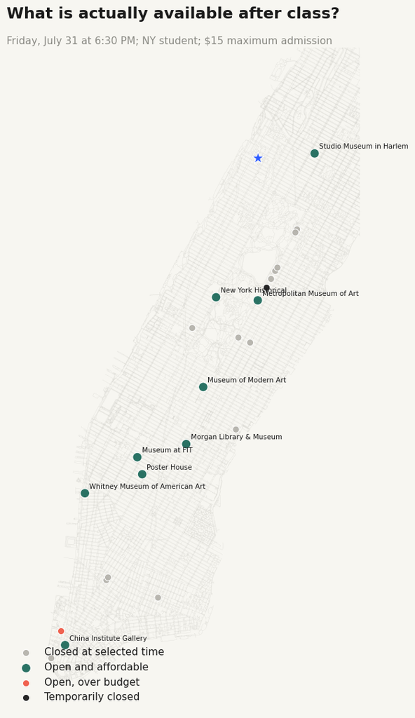

```python
status_colors = {
    "Open and affordable": GREEN,
    "Open, over budget": CORAL,
    "Closed at selected time": "#B5B3AC",
    "Temporarily closed": INK,
}

fig, ax = plt.subplots(figsize=(9, 11))
edges.plot(ax=ax, color="#DEDDD7", linewidth=0.18, alpha=0.65, zorder=1)
for status, group in scenario.groupby("status"):
    group.plot(
        ax=ax,
        color=status_colors[status],
        markersize=np.where(group["fits"], 100, 55),
        edgecolor="white",
        linewidth=0.8,
        alpha=0.95,
        label=status,
        zorder=3,
    )

for _, row in scenario.loc[scenario["fits"]].iterrows():
    ax.annotate(
        row["name"].replace("The ", ""),
        (row.geometry.x, row.geometry.y),
        xytext=(5, 5),
        textcoords="offset points",
        fontsize=7.5,
        color=INK,
    )

ax.scatter(
    -73.96255,
    40.80766,
    marker="*",
    s=180,
    color=BLUE,
    edgecolor="white",
    linewidth=0.8,
    zorder=4,
)
ax.set_xlim(-74.03, -73.935)
ax.set_ylim(40.695, 40.83)
ax.set_title(
    "What is actually available after class?",
    loc="left",
    fontsize=17,
    pad=32,
)
ax.text(
    0,
    1.005,
    "Friday, July 31 at 6:30 PM; NY student; $15 maximum admission",
    transform=ax.transAxes,
    color=MUTED,
)
ax.axis("off")
ax.legend(loc="lower left", frameon=False)
fig.tight_layout()
fig.savefig(FIGURE_DIR / "02_friday_evening_access.png", dpi=180, bbox_inches="tight")
plt.show()
```

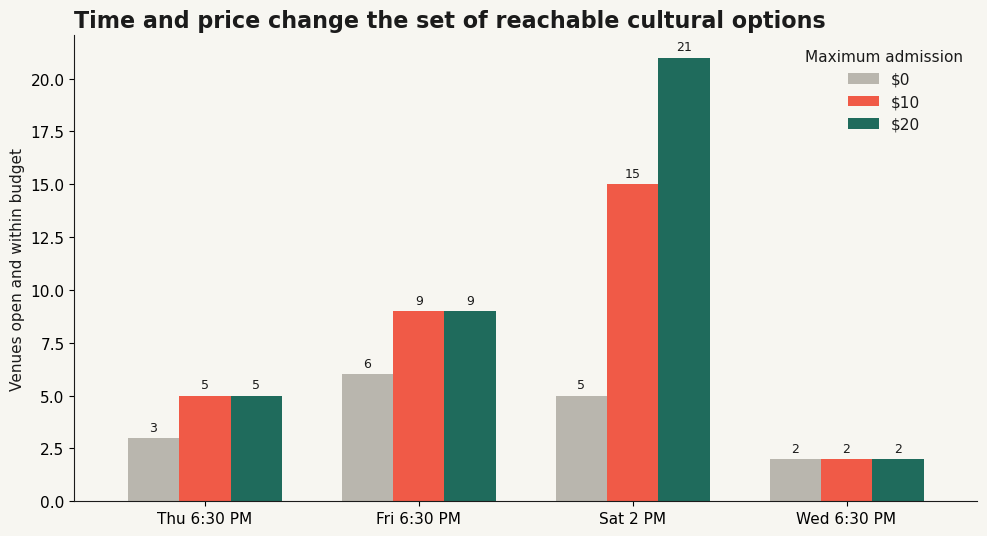

```python
scenario_inputs = [
    ("Thu 6:30 PM", dt.date(2026, 7, 23), 18.5),
    ("Fri 6:30 PM", dt.date(2026, 7, 24), 18.5),
    ("Sat 2 PM", dt.date(2026, 7, 25), 14),
    ("Wed 6:30 PM", dt.date(2026, 7, 29), 18.5),
]
budgets = [0, 10, 20]
availability_rows = []

for label, date_value, time_value in scenario_inputs:
    for budget_value in budgets:
        evaluated = venues.apply(
            evaluate_venue,
            axis=1,
            selected_date=date_value,
            selected_time=time_value,
            budget=budget_value,
            profile=profile,
        )
        availability_rows.append(
            {
                "scenario": label,
                "budget": budget_value,
                "available_venues": int(evaluated["fits"].sum()),
            }
        )

availability = pd.DataFrame(availability_rows)
pivot = availability.pivot(index="scenario", columns="budget", values="available_venues")
pivot = pivot.reindex([item[0] for item in scenario_inputs])

fig, ax = plt.subplots(figsize=(10, 5.5))
pivot.plot(
    kind="bar",
    ax=ax,
    color=["#B9B6AE", CORAL, GREEN],
    width=0.72,
)
ax.set_title("Time and price change the set of reachable cultural options", loc="left", fontsize=16)
ax.set_xlabel("")
ax.set_ylabel("Venues open and within budget")
ax.legend(title="Maximum admission", labels=["$0", "$10", "$20"], frameon=False)
ax.tick_params(axis="x", rotation=0)
ax.spines[["top", "right"]].set_visible(False)
for container in ax.containers:
    ax.bar_label(container, padding=3, fontsize=9)
fig.tight_layout()
fig.savefig(FIGURE_DIR / "03_access_by_time_and_budget.png", dpi=180, bbox_inches="tight")
plt.show()
```

The comparison above shows why proximity alone is insufficient. Saturday afternoon offers many more choices, while a weekday evening can shrink the available set even before travel is considered. Increasing the budget helps only where venues are still open.

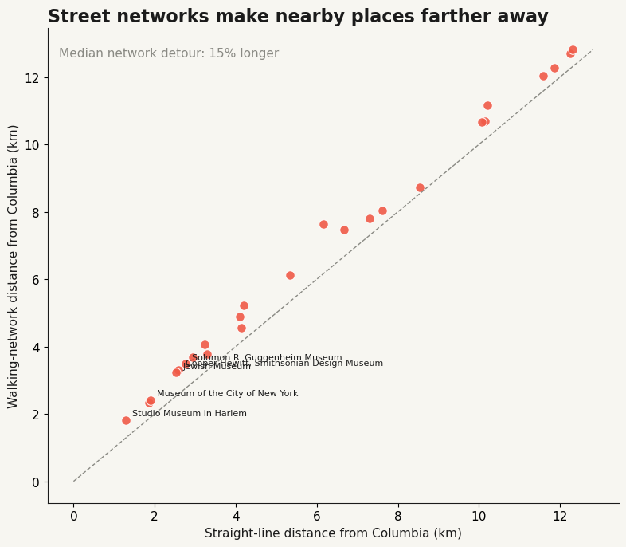

```python
fig, ax = plt.subplots(figsize=(8, 7))
ax.scatter(
    venues["columbia_euclidean_m"] / 1000,
    venues["columbia_walk_network_m"] / 1000,
    s=70,
    color=CORAL,
    edgecolor="white",
    linewidth=0.8,
    alpha=0.9,
)

limit = max(
    venues["columbia_euclidean_m"].max(),
    venues["columbia_walk_network_m"].max(),
) / 1000
ax.plot([0, limit], [0, limit], linestyle="--", color=MUTED, linewidth=1)

largest_detours = venues.nlargest(5, "network_detour_ratio")
for _, row in largest_detours.iterrows():
    ax.annotate(
        row["name"].replace("The ", ""),
        (row["columbia_euclidean_m"] / 1000, row["columbia_walk_network_m"] / 1000),
        xytext=(6, 4),
        textcoords="offset points",
        fontsize=8,
    )

ax.set_title("Street networks make nearby places farther away", loc="left", fontsize=16)
ax.set_xlabel("Straight-line distance from Columbia (km)")
ax.set_ylabel("Walking-network distance from Columbia (km)")
ax.spines[["top", "right"]].set_visible(False)
ax.text(
    0.02,
    0.96,
    f"Median network detour: {(venues['network_detour_ratio'].median() - 1) * 100:.0f}% longer",
    transform=ax.transAxes,
    va="top",
    color=MUTED,
)
fig.tight_layout()
fig.savefig(FIGURE_DIR / "04_euclidean_vs_network.png", dpi=180, bbox_inches="tight")
plt.show()
```

Euclidean distance answers a geometric question: how far apart are two coordinates? Network distance answers an experiential question: how far must a person travel along available paths? The largest differences occur where park edges, blocks, entrances, or street geometry prevent a direct route.

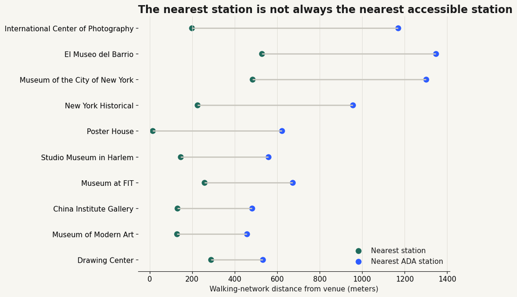

```python
ada_gap = venues.assign(
    ada_gap_m=venues["ada_station_walk_m"] - venues["station_walk_m"]
).nlargest(10, "ada_gap_m")

fig, ax = plt.subplots(figsize=(10, 6.5))
y = np.arange(len(ada_gap))
ax.hlines(
    y,
    ada_gap["station_walk_m"],
    ada_gap["ada_station_walk_m"],
    color="#C9C7BF",
    linewidth=2,
)
ax.scatter(ada_gap["station_walk_m"], y, color=GREEN, s=65, label="Nearest station")
ax.scatter(ada_gap["ada_station_walk_m"], y, color=BLUE, s=65, label="Nearest ADA station")
ax.set_yticks(y)
ax.set_yticklabels(ada_gap["name"].str.replace("^The ", "", regex=True))
ax.invert_yaxis()
ax.set_xlabel("Walking-network distance from venue (meters)")
ax.set_title("The nearest station is not always the nearest accessible station", loc="left", fontsize=16)
ax.legend(frameon=False, loc="lower right")
ax.spines[["top", "right", "left"]].set_visible(False)
ax.grid(axis="x", color="#DFDDD6", linewidth=0.7)
fig.tight_layout()
fig.savefig(FIGURE_DIR / "05_ada_station_gap.png", dpi=180, bbox_inches="tight")
plt.show()
```

## Coverage, scale, and data honesty

The full DCLA dataset contains 2,535 funded cultural organizations, including 2,268 records (89.5%) with usable coordinates. That citywide layer is valuable for understanding institutional concentration, but it does **not** reliably provide public entrances, current hours, admission, or visitable programming.

The final product therefore uses 161 individually screened public places rather than showing the full directory as though every record were a destination. All 161 have source-backed admission and opening-schedule information; 106 have structured weekly hours, and a 25-venue analytical pilot also has detailed discount rules for reproducible scenario analysis. For event and screening venues, the honest value is often a schedule or pricing structure rather than one false fixed ticket price.

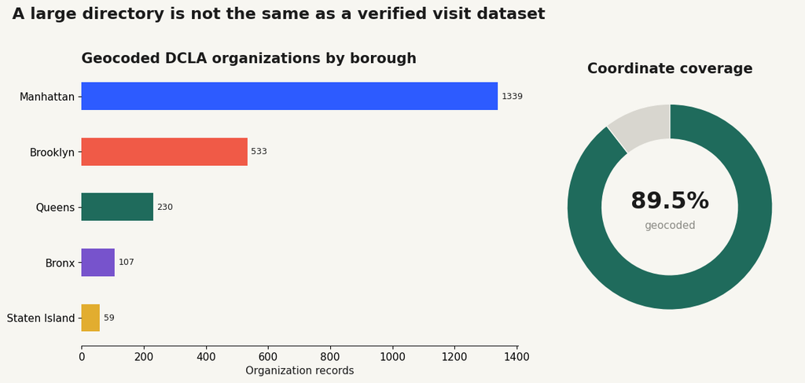

```python
borough_order = ["Manhattan", "Brooklyn", "Queens", "Bronx", "Staten Island"]
borough_counts = (
    directory["borough"]
    .value_counts()
    .reindex(borough_order)
    .fillna(0)
    .astype(int)
)

fig, axes = plt.subplots(
    1,
    2,
    figsize=(12, 5.5),
    gridspec_kw={"width_ratios": [1.7, 1]},
)
borough_counts.plot(
    kind="barh",
    ax=axes[0],
    color=[BLUE, CORAL, GREEN, "#7753CC", "#E2AD2F"],
)
axes[0].invert_yaxis()
axes[0].set_title("Geocoded DCLA organizations by borough", loc="left", fontsize=15)
axes[0].set_xlabel("Organization records")
axes[0].set_ylabel("")
axes[0].spines[["top", "right", "left"]].set_visible(False)
for container in axes[0].containers:
    axes[0].bar_label(container, padding=4, fontsize=9)

coverage_values = [
    summary["dcla_geocoded_count"],
    summary["dcla_row_count"] - summary["dcla_geocoded_count"],
]
axes[1].pie(
    coverage_values,
    colors=[GREEN, "#D8D6CF"],
    startangle=90,
    counterclock=False,
    wedgeprops={"width": 0.34, "edgecolor": PAPER},
)
axes[1].text(
    0,
    0.05,
    f"{summary['dcla_geocoded_percent']:.1f}%",
    ha="center",
    va="center",
    fontsize=24,
    fontweight="bold",
)
axes[1].text(0, -0.18, "geocoded", ha="center", va="center", color=MUTED)
axes[1].set_title("Coordinate coverage", fontsize=15)

fig.suptitle(
    "A large directory is not the same as a verified visit dataset",
    x=0.02,
    y=1.02,
    ha="left",
    fontsize=17,
    fontweight="bold",
)
fig.tight_layout()
fig.savefig(FIGURE_DIR / "06_directory_coverage.png", dpi=180, bbox_inches="tight")
plt.show()
```

## Schedule-weighted subway network

The subway network is not a straight line between a starting point and a venue. Each node represents a **station-line state** such as `116 St | 1`, so changing lines requires an explicit transfer edge. Consecutive GTFS stop times provide segment weights. A route starts at the nearest station, includes a four-minute initial wait, compares up to eight destination stations, and adds the final walk.

This model contains 1,002 station-line nodes and 4,337 directed edges. It is more experiential than Euclidean distance, but it remains a typical-weekday model rather than a real-time MTA prediction.

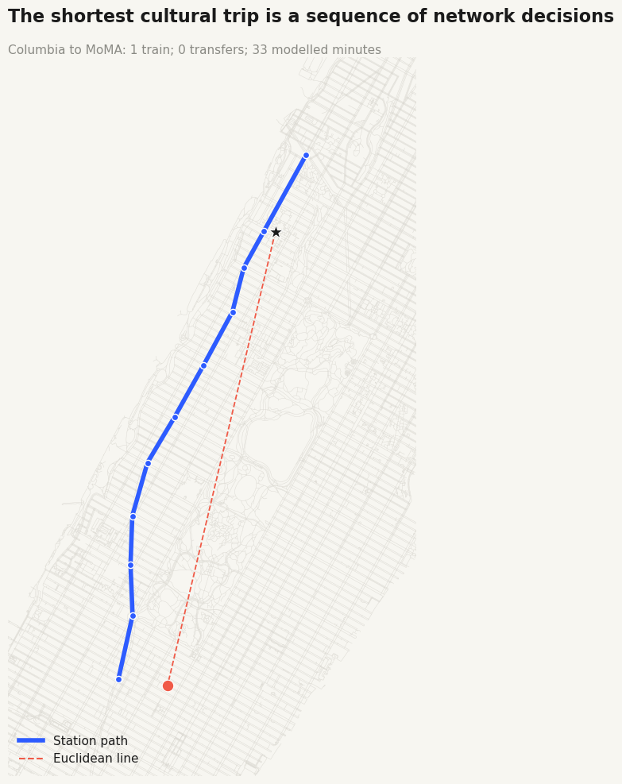

```python
example_name = "The Museum of Modern Art"
example_route = transit_routes.loc[
    transit_routes["venue_name"] == example_name
].iloc[0]
example_venue = venues.loc[venues["name"] == example_name].iloc[0]
route_station_ids = (
    json.loads(example_route["station_path"])
    if isinstance(example_route["station_path"], str)
    else example_route["station_path"]
)
route_stations = stations.loc[
    stations["gtfs_stop_id"].astype(str).isin(
        [str(value) for value in route_station_ids]
    )
]

fig, ax = plt.subplots(figsize=(8.5, 10))
edges.plot(ax=ax, color="#DEDCD5", linewidth=0.25, alpha=0.8, zorder=1)
gpd.GeoSeries([example_route.geometry], crs=4326).plot(
    ax=ax,
    color=BLUE,
    linewidth=4,
    zorder=3,
)
route_stations.plot(
    ax=ax,
    color=BLUE,
    edgecolor="white",
    linewidth=1,
    markersize=35,
    zorder=4,
)
ax.plot(
    [-73.96255, example_venue.geometry.x],
    [40.80766, example_venue.geometry.y],
    linestyle="--",
    color=CORAL,
    linewidth=1.3,
    label="Euclidean line",
    zorder=2,
)
ax.scatter(
    [-73.96255],
    [40.80766],
    marker="*",
    s=180,
    color=INK,
    edgecolor="white",
    linewidth=0.8,
    zorder=5,
)
ax.scatter(
    [example_venue.geometry.x],
    [example_venue.geometry.y],
    s=110,
    color=CORAL,
    edgecolor="white",
    linewidth=0.8,
    zorder=5,
)
route_bounds = example_route.geometry.bounds
ax.set_xlim(route_bounds[0] - 0.015, route_bounds[2] + 0.015)
ax.set_ylim(route_bounds[1] - 0.01, route_bounds[3] + 0.01)
ax.set_title(
    "The shortest cultural trip is a sequence of network decisions",
    loc="left",
    fontsize=16,
    pad=32,
)
ax.text(
    0,
    1.005,
    (
        f"Columbia to MoMA: {example_route['route_names']} train; "
        f"{example_route['transfer_count']} transfers; "
        f"{example_route['total_minutes']:.0f} modelled minutes"
    ),
    transform=ax.transAxes,
    color=MUTED,
)
ax.axis("off")
ax.legend(
    handles=[
        Line2D([0], [0], color=BLUE, linewidth=4, label="Station path"),
        Line2D([0], [0], color=CORAL, linestyle="--", label="Euclidean line"),
    ],
    loc="lower left",
    frameon=False,
)
fig.tight_layout()
fig.savefig(FIGURE_DIR / "07_subway_route_example.png", dpi=180, bbox_inches="tight")
plt.show()
```

|  | name | euclidean_km | walking_network_km | walking_minutes | columbia_transit_total_min | columbia_transit_routes | columbia_transit_transfer_count |
| --- | --- | --- | --- | --- | --- | --- | --- |
| 18 | American Folk Art Museum | 4.1 | 4.6 | 57.0 | 24.0 | 1 | 0 |
| 13 | The New York Historical | 3.3 | 3.8 | 47.4 | 29.1 | 1 | 0 |
| 15 | Studio Museum in Harlem | 1.3 | 1.8 | 22.7 | 30.0 | 1 3 | 1 |
| 19 | The Museum at FIT | 7.3 | 7.8 | 97.6 | 30.4 | 1 2 | 1 |
| 14 | Poster House | 7.6 | 8.0 | 100.4 | 32.6 | 1 2 | 1 |
| 11 | The Museum of Modern Art | 5.3 | 6.1 | 76.6 | 33.1 | 1 | 0 |
| 22 | El Museo del Barrio | 1.8 | 2.3 | 29.2 | 35.0 | 1 2 | 1 |
| 23 | Museum of the City of New York | 1.9 | 2.4 | 30.2 | 36.3 | 1 2 | 1 |
| 9 | The Morgan Library & Museum | 6.7 | 7.5 | 93.3 | 37.1 | 1 3 S | 2 |
| 20 | Leslie-Lohman Museum of Art | 10.2 | 10.7 | 133.5 | 38.8 | 1 2 | 1 |

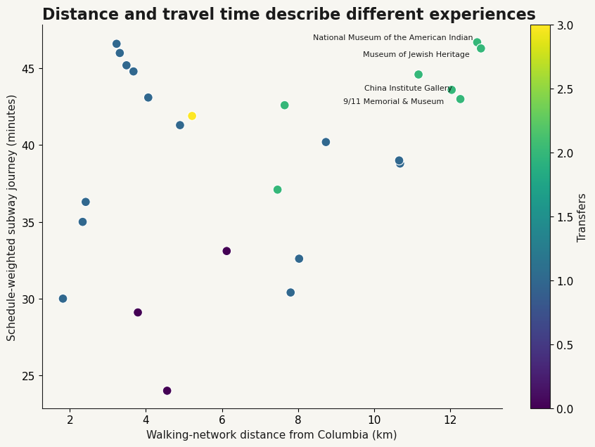

```python
distance_comparison = venues[
    [
        "name",
        "columbia_euclidean_m",
        "columbia_walk_network_m",
        "columbia_transit_total_min",
        "columbia_transit_routes",
        "columbia_transit_transfer_count",
    ]
].copy()
distance_comparison["euclidean_km"] = (
    distance_comparison["columbia_euclidean_m"] / 1000
)
distance_comparison["walking_network_km"] = (
    distance_comparison["columbia_walk_network_m"] / 1000
)
distance_comparison["walking_minutes"] = (
    distance_comparison["columbia_walk_network_m"] / 80
)
distance_comparison["minutes_saved_by_subway"] = (
    distance_comparison["walking_minutes"]
    - distance_comparison["columbia_transit_total_min"]
)

display(
    distance_comparison[
        [
            "name",
            "euclidean_km",
            "walking_network_km",
            "walking_minutes",
            "columbia_transit_total_min",
            "columbia_transit_routes",
            "columbia_transit_transfer_count",
        ]
    ]
    .sort_values("columbia_transit_total_min")
    .head(10)
    .round(1)
)

fig, ax = plt.subplots(figsize=(9, 6.5))
scatter = ax.scatter(
    distance_comparison["walking_network_km"],
    distance_comparison["columbia_transit_total_min"],
    c=distance_comparison["columbia_transit_transfer_count"],
    cmap="viridis",
    s=85,
    edgecolor="white",
    linewidth=0.8,
)
for label_index, (_, row) in enumerate(
    distance_comparison.nlargest(4, "minutes_saved_by_subway").iterrows()
):
    ax.annotate(
        row["name"].replace("The ", ""),
        (row["walking_network_km"], row["columbia_transit_total_min"]),
        xytext=(-8, [9, -14, 9, -14][label_index]),
        textcoords="offset points",
        fontsize=8,
        ha="right",
    )
ax.set_title(
    "Distance and travel time describe different experiences",
    loc="left",
    fontsize=16,
)
ax.set_xlabel("Walking-network distance from Columbia (km)")
ax.set_ylabel("Schedule-weighted subway journey (minutes)")
ax.spines[["top", "right"]].set_visible(False)
colorbar = fig.colorbar(scatter, ax=ax)
colorbar.set_label("Transfers")
fig.tight_layout()
fig.savefig(FIGURE_DIR / "08_walking_vs_transit.png", dpi=180, bbox_inches="tight")
plt.show()
```

## A transparent, personalized access score

The sensitivity analysis below tests the earlier four-component pilot score: availability, cost, journey, and ADA-station proximity. It demonstrates that there is no neutral ranking because the same venues move when weights change.

The current public interface extends this logic with a fifth component: **interest match**. Its default profile weights journey at 35%, interest at 25%, availability at 20%, cost at 10%, and ADA-station proximity at 10%. A step-free profile changes those weights, while an optional smaller-space preference boosts artist-run, nonprofit, residency, and community venues. The interface exposes these choices instead of presenting one universal ranking.

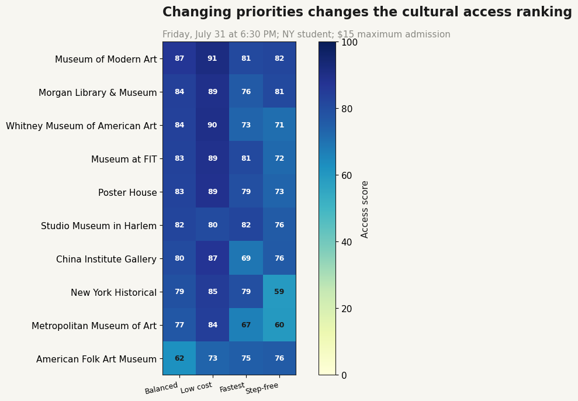

```python
PRESETS = {
    "Balanced": {"availability": 35, "cost": 25, "transit": 25, "ada": 15},
    "Low cost": {"availability": 25, "cost": 50, "transit": 15, "ada": 10},
    "Fastest": {"availability": 20, "cost": 10, "transit": 60, "ada": 10},
    "Step-free": {"availability": 20, "cost": 15, "transit": 20, "ada": 45},
}


def access_components(row, selected_time, selected_budget):
    remaining_hours = (
        max(0, row["closes_at"] - selected_time)
        if row["is_open"] and pd.notna(row["closes_at"])
        else 0
    )
    availability_score = (
        np.clip(70 + remaining_hours * 10, 70, 100)
        if row["is_open"]
        else 0
    )
    budget_base = max(selected_budget, 1)
    if row["effective_price"] <= selected_budget:
        cost_score = np.clip(
            100 - row["effective_price"] / budget_base * 40,
            60,
            100,
        )
    else:
        cost_score = np.clip(
            50
            - (row["effective_price"] - selected_budget)
            / budget_base
            * 50,
            0,
            50,
        )
    transit_score = np.clip(
        100 - (row["columbia_transit_total_min"] - 20) / 55 * 100,
        0,
        100,
    )
    ada_score = np.clip(
        100 - (row["ada_station_walk_m"] - 200) / 1000 * 100,
        0,
        100,
    )
    return {
        "availability": availability_score,
        "cost": cost_score,
        "transit": transit_score,
        "ada": ada_score,
    }


score_table = scenario[["name"]].copy()
for preset_name, weights in PRESETS.items():
    scores = []
    for _, row in scenario.iterrows():
        components = access_components(row, selected_time, budget)
        scores.append(
            sum(components[key] * value for key, value in weights.items())
            / sum(weights.values())
        )
    score_table[preset_name] = scores

top_names = (
    score_table.set_index("name")["Balanced"]
    .nlargest(10)
    .index
)
score_plot = score_table.set_index("name").loc[top_names]

fig, ax = plt.subplots(figsize=(9.5, 7))
image = ax.imshow(score_plot.values, cmap="YlGnBu", vmin=0, vmax=100)
ax.set_xticks(np.arange(len(score_plot.columns)))
ax.set_xticklabels(score_plot.columns)
ax.set_yticks(np.arange(len(score_plot.index)))
ax.set_yticklabels(
    score_plot.index.str.replace("^The ", "", regex=True)
)
for row_index in range(score_plot.shape[0]):
    for column_index in range(score_plot.shape[1]):
        value = score_plot.iloc[row_index, column_index]
        ax.text(
            column_index,
            row_index,
            f"{value:.0f}",
            ha="center",
            va="center",
            color="white" if value > 68 else INK,
            fontsize=9,
            fontweight="bold",
        )
ax.set_title(
    "Changing priorities changes the cultural access ranking",
    loc="left",
    fontsize=16,
    pad=32,
)
ax.text(
    0,
    1.015,
    "Friday, July 31 at 6:30 PM; NY student; $15 maximum admission",
    transform=ax.transAxes,
    color=MUTED,
)
fig.colorbar(image, ax=ax, label="Access score")
ax.tick_params(axis="x", labelsize=9, rotation=12)
for tick_label in ax.get_xticklabels():
    tick_label.set_ha("right")
fig.tight_layout()
fig.savefig(FIGURE_DIR / "09_score_sensitivity.png", dpi=180, bbox_inches="tight")
plt.show()
```

## Takeaways

1. **Abundance is not access.** The product can route to 161 screened cultural places, but route availability alone cannot establish that a venue is open, affordable, or socially welcoming.
2. **Hours are a structural barrier.** Several free or suggested-admission pilot venues close by 5 or 6 PM, reducing after-work and after-class access.
3. **Price programs can reverse the map.** Weekly free nights can make a normally expensive institution more practical than a low-cost venue that is already closed.
4. **The nearest station is not always the best station.** Comparing multiple destination stations avoids routes with unnecessary transfers.
5. **ADA access changes proximity.** The median nearest-station walk rises from 394 to 604 meters when the destination station must be ADA-accessible.
6. **Rankings are choices.** Journey, interest, availability, cost, mobility, and preference for smaller spaces produce different recommendation orders.
7. **Current programming needs provenance.** The 16-program editorial sample links to official pages and expires by date rather than pretending to be an error-free live ticket feed.
8. **Coverage must remain visible.** The 161-place public layer, the 25-profile analytical layer, and the 2,268-point directory answer different questions.

### What this analysis cannot tell us

The data cannot measure how welcoming a venue feels, cultural relevance, language access, crowding, personal safety, event sellouts, or full physical accessibility. The network excludes live service changes, elevator outages, buses, ferries, and platform-level paths. Official event pages and real-world directions remain necessary for confirmation.

## Public-use product extension

The final interface turns the analytical method into an everyday cultural planner. Before treating the expanded layer as usable, the checks below verify that every record has the core public information required by the product and that every current program resolves to a known venue.

|  | value |
| --- | --- |
| screened public places | 161 |
| public structured weekly schedules | 106 |
| analytical pilot profiles | 25 |
| date-checked current programs | 16 |
| missing required public fields | 0 |
| duplicate place ids | 0 |
| programs with unknown venue ids | 0 |

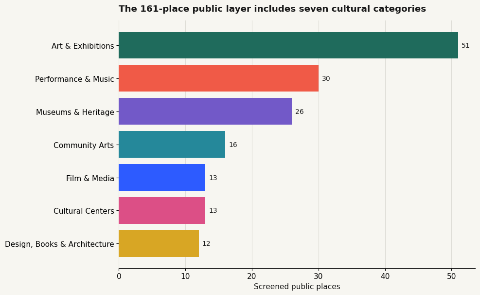

```python
required_public_fields = [
    "id",
    "name",
    "category",
    "venue_type",
    "borough",
    "neighborhood",
    "description",
    "address",
    "website",
    "events_url",
    "schedule_type",
    "hours_label",
    "admission_label",
    "visit_source",
    "visit_checked",
]

missing_by_field = public_places[required_public_fields].isna().sum()
duplicate_ids = int(public_places["id"].duplicated().sum())
unknown_program_venues = sorted(
    set(current_programs["venue_id"]) - set(public_places["id"])
)
public_structured_hours = int(public_places["hours"].notna().sum())

product_checks = pd.Series(
    {
        "screened public places": len(public_places),
        "public structured weekly schedules": public_structured_hours,
        "analytical pilot profiles": len(venues),
        "date-checked current programs": len(current_programs),
        "missing required public fields": int(missing_by_field.sum()),
        "duplicate place ids": duplicate_ids,
        "programs with unknown venue ids": len(unknown_program_venues),
    },
    name="value",
).to_frame()
display(product_checks)

assert len(public_places) == 161
assert public_structured_hours == 106
assert len(venues) == 25
assert len(current_programs) == 16
assert missing_by_field.sum() == 0
assert duplicate_ids == 0
assert not unknown_program_venues

category_counts = public_places["category"].value_counts().sort_values()
category_colors = {
    "Art & Exhibitions": GREEN,
    "Museums & Heritage": "#7259C8",
    "Performance & Music": CORAL,
    "Film & Media": BLUE,
    "Cultural Centers": "#DC4F86",
    "Design, Books & Architecture": "#D8A624",
    "Community Arts": "#25889A",
}

fig, ax = plt.subplots(figsize=(10, 6.2))
bars = ax.barh(
    category_counts.index,
    category_counts.values,
    color=[category_colors.get(label, GREEN) for label in category_counts.index],
)
ax.bar_label(bars, padding=5, fontsize=10)
ax.set_title("The 161-place public layer includes seven cultural categories", loc="left", pad=14)
ax.set_xlabel("Screened public places")
ax.spines[["top", "right", "left"]].set_visible(False)
ax.grid(axis="x", color="#DDDCD5", linewidth=0.8)
ax.set_axisbelow(True)
fig.tight_layout()
fig.savefig(FIGURE_DIR / "10_public_place_categories.png", dpi=180, bbox_inches="tight")
plt.show()
```

The expanded layer is intentionally broader than a museum directory. Art and exhibition spaces are the largest category, but film, performance, design and books, cultural centers, community arts, and heritage venues remain visible. This diversity is also why personalization matters: one global ranking would treat very different cultural intentions as equivalent.

The zero-missing-field and zero-unmatched-program checks support the interface handoff. They do not predict daily schedule changes, event sellouts, or live transit conditions; official program links remain attached for confirmation.

## Sources

- [NYC DCLA Cultural Organizations](https://data.cityofnewyork.us/Recreation/DCLA-Cultural-Organizations/u35m-9t32)
- [NYC DCLA Free and Suggested Admission](https://www.nyc.gov/site/dcla/resources/free-and-suggested-admission.page)
- [MTA Subway Stations](https://data.ny.gov/Transportation/MTA-Subway-Stations/39hk-dx4f)
- [MTA Static GTFS](https://data.ny.gov/Transportation/MTA-General-Transit-Feed-Specification-GTFS-Static/fgm6-ccue)
- [OpenStreetMap](https://www.openstreetmap.org/) walking network via OSMnx
- Individually screened venue sources are stored in `data/curated_places.json`.
- Current program records and official event links are stored in `data/current_programs.json`.